```python
#TAFLAMPAS NIKOLAOS 4500
import json
import pandas as pd
import csv
import matplotlib.pyplot as plt
from matplotlib import cm
import math
import datetime
import scipy.stats as stats
import re
import seaborn as sns
import numpy as np
from scipy.spatial import distance
```

# Data Loading

### **(!)As a future reference, all code has been commented on for further clarification. All markdown has been written only for a general overview of each section.(!)**

With the dataset being too large, we find that simply opening the file is impossible. Thus we start streaming each line, reading all neccecary and writing it on a seperate file.

### Filtered Businesses

The CSV of filtered businesses, contains all businesses from Philadelphia that contain no Null/None values. This seperation was done during the filtering instead of relying on Pandas. We translate each line into its JSON equivilant, and check if there is a None value. If there is, we throw it out. If there's not, we check if it's from Philadelphia, and if it is we add it to the CSV. Note, that we also store in our memory the Business ID for the reviews. If there were too many businesses to keep their IDs in memory, a similar Streaming tactic would have been needed.

### Filtered Reviews

The CSV of filtered reviews, contains all reviews that belong to the businesses of Filtere Businesses CSV. The process is similar from the above, with the only difference being that we drop all reviews that don't have a business_id field that has a match in our businessIDs list from the previous step.

**Note: All data filtering, especially for the reviews, takes a good while. Roughly 30 minutes is required for all the filtering, so be patient.**

```python
#Step 1: Stream-Read Business Dataset, Filter the IDs from Philadelphia, Store them to fetch businesses.
outputFileBusiness = open("filtered_business.csv", 'w', newline='')
businessIDs = []

with open("yelp_academic_dataset_business.json", errors="ignore") as f:
    buffer = ["business_id","name","address","city","state","postal code", "latitude",
              "longitude", "stars", "review_count", "is_open", "attributes",
              "categories","hours"]
    writer = csv.writer(outputFileBusiness)
    writer.writerow(buffer)
    buffer = []

    for line in f:
        jsonLine = json.loads(line.strip())

        hasNullValue = False
        for i in jsonLine:
            if jsonLine[i] == None:
                hasNullValue = True
                break

        if hasNullValue:
            continue

        if jsonLine["city"] == "Philadelphia":
            temp = ""
            for i in jsonLine:
                buffer.append(str(jsonLine[i]).strip())
                if i == "business_id":
                    businessIDs.append(str(jsonLine[i]).strip())
            writer.writerow(buffer)
            buffer = []
outputFileBusiness.close()
print("Done")
```

```python
#Step 2, Using the business IDs, we find the matching reviews (ignoring those with NULL values). We write them in another CSV
#!WARNING! This takes a LOOOONG time. It produces the filtered reviews file. Be warned.
outputFileReviews = open("filtered_reviews.csv", "w", newline='')

with open("yelp_academic_dataset_review.json", errors="ignore") as f:
    buffer = ["review_id", "user_id", "business_id", "stars",
              "useful", "funny", "cool", "text", "date"]
    writer = csv.writer(outputFileReviews)
    writer.writerow(buffer)
    buffer = []
    counter = 0
    for line in f:
        counter += 1
        try:
            jsonLine = json.loads(line.strip())
        except:
            print(str(counter) + "\n" + line) #Should be removed. Some lines are not good, so we ignore them.
            continue

        hasNullValue = False
        for i in jsonLine:
            if jsonLine[i] == None:
                hasNullValue = True
                break

        if hasNullValue:
            continue

        if jsonLine["business_id"] in businessIDs:
            temp = ""
            for i in jsonLine:
                buffer.append(str(jsonLine[i]).strip().replace("\n", " "))
            writer.writerow(buffer)
            buffer = []
outputFileReviews.close()
print("Done.")
```

```
6978776
{"review_id":"JhpyZQCnjGTtMJTvDwfMFw","user_id":"XQY8nfYJy33R1vFjyIHB9w","business_id":"U5M36rcw9Nad75h3WbX5jg","stars":1.0,"useful":3,"funny":0,"cool":0,"text":"I wish i could put 0 stars. I pu
Done.
```

# Runnables

We can't really afford running the data filtering every singly time, so for convinience, we use the following 2 cells to load in the variables "businessData" and "reviewsData" all the required information.

```python
#Set Up Business Data. Always run this when opening the Notebook
businessData = pd.read_csv("filtered_business.csv", encoding="latin")
businessData["categories"] = businessData["categories"].apply(lambda x: x.split(","))

print(businessData.info()) #Info regarding the Businesses.
```

```
<class 'pandas.core.frame.DataFrame'>
RangeIndex: 11070 entries, 0 to 11069
Data columns (total 14 columns):
 #   Column        Non-Null Count  Dtype
---  ------        --------------  -----
 0   business_id   11070 non-null  object
 1   name          11070 non-null  object
 2   address       10694 non-null  object
 3   city          11070 non-null  object
 4   state         11070 non-null  object
 5   postal code   11066 non-null  float64
 6   latitude      11070 non-null  float64
 7   longitude     11070 non-null  float64
 8   stars         11070 non-null  float64
 9   review_count  11070 non-null  int64
 10  is_open       11070 non-null  int64
 11  attributes    11070 non-null  object
 12  categories    11070 non-null  object
 13  hours         11070 non-null  object
dtypes: float64(4), int64(2), object(8)
memory usage: 1.2+ MB
None
```

```python
#Set up the ReviewsData. Always run this when opening the Notebook
reviewsData = pd.read_csv("filtered_reviews.csv", encoding="latin")
reviewsData["date"] = pd.to_datetime(reviewsData["date"])

print(reviewsData.info()) #Info regarding the Reviews. Should be 893906 reviews from Philadelphia
```

```
<class 'pandas.core.frame.DataFrame'>
RangeIndex: 893906 entries, 0 to 893905
Data columns (total 9 columns):
 #   Column       Non-Null Count   Dtype
---  ------       --------------   -----
 0   review_id    893906 non-null  object
 1   user_id      893906 non-null  object
 2   business_id  893906 non-null  object
 3   stars        893906 non-null  float64
 4   useful       893906 non-null  int64
 5   funny        893906 non-null  int64
 6   cool         893906 non-null  int64
 7   text         893906 non-null  object
 8   date         893906 non-null  datetime64[ns]
dtypes: datetime64[ns](1), float64(1), int64(3), object(4)
memory usage: 61.4+ MB
None
```

# Part A: Distribution

For Part A, we try to figure the general distribution of our review_count field within businessData.

## Probability Density Function

The function is the result of plotting the line roughly above the second histogram. This is to be expected, as the PDF must have the highest density around the start of the plot, and fall off at the end.

## Zipf Function

The Zipf graph simply provides us with the image of frequency amongst our data. Now much else can be said about it, besides following the Zipf's law.

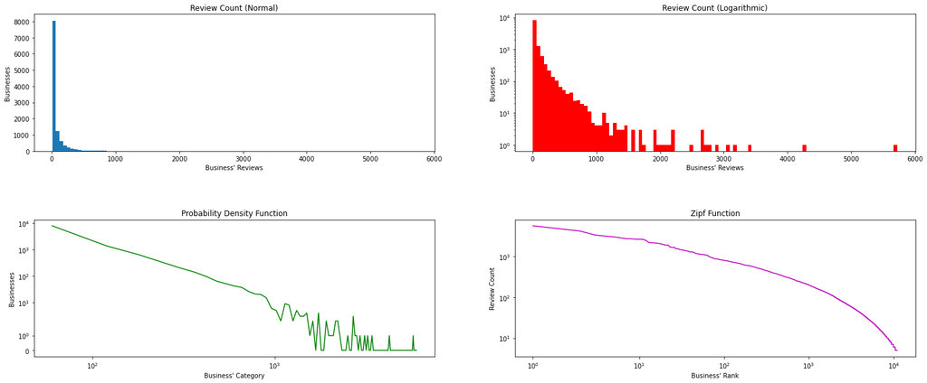

```python
#Part A
figure = plt.figure(figsize=(25,10))
plt.subplots_adjust(hspace=0.5)
#This data is decent if zoomed-in, but some values do not show. For example, there are a few businesses with
#more than 5000 reviews in this graph.
plt.subplot(221)
plt.hist(businessData["review_count"], bins=100)
plt.title("Review Count (Normal)")
plt.xlabel("Business' Reviews")
plt.ylabel("Businesses")

#While more chaotic, this does actually show the few businesses with more than 5000 reviews~!
plt.subplot(222)
plt.hist(businessData["review_count"], bins=100, log=True, color="r")
plt.title("Review Count (Logarithmic)")
plt.xlabel("Business' Reviews")
plt.ylabel("Businesses")


#A note to be made here is that the function should be just a line above our Log Histograph. It's not, since we used
#the log scaling in both axises. Removing the xscale gives better results, however as asked in the exercise, both
#axises use a logarithmic scaling.
plt.subplot(223)
categories = [i*(6000/100) for i in range(1,101)]
businessCounter = [0]*100
for count in businessData["review_count"]:
    for i in range(len(categories)):
        if int(count) < categories[i]:
            businessCounter[i] += 1
            break

plt.plot(categories, businessCounter, color="g")
plt.yscale('symlog')
plt.xscale('symlog') #<---Remove for better results
plt.title("Probability Density Function")
plt.xlabel("Business' Category")
plt.ylabel("Businesses")


#Zipf Plot. Once more, the xscale kind of messes with the results. But the idea remains the same.
plt.subplot(224)
plt.plot(range(1,len(businessData["review_count"])+1),
         businessData["review_count"].sort_values(ascending=False).to_numpy(),
         color="m")
plt.xscale('symlog') #<--- Remove for better results
plt.yscale('symlog')
plt.title("Zipf Function")
plt.xlabel("Business' Rank")
null = plt.ylabel("Review Count")
```

## Part B: Ratings over Time

On this part, we test the star rating growth over the duration of time, across all businesses. The proccesses is as follows:

- For each business, we find the first review's date and store it
- We then merge the first date with each review according to its business
- For each review, we find the difference between it and the first review.
- We divide the difference by 30 to find its index
- We Group the reviews by index and find the mean star rating

Having done, that we plot the data. At the first graph we see a faint slope downwards which dissapears at the second one. This can tell us that businesses tend to start off with a larger star rating, but overtime return to the general mean, which is around 3.75. Overtime, the mean stays the same. But around 200 months, most businesses have died down. This gives the few businesses that remain the drive over our mean, thus making the data way more chaotic.

The Second graph reinforces our first point. Businesses start off with more stars the first ~20 months, and gradually fall off to the general mean after that time limit.

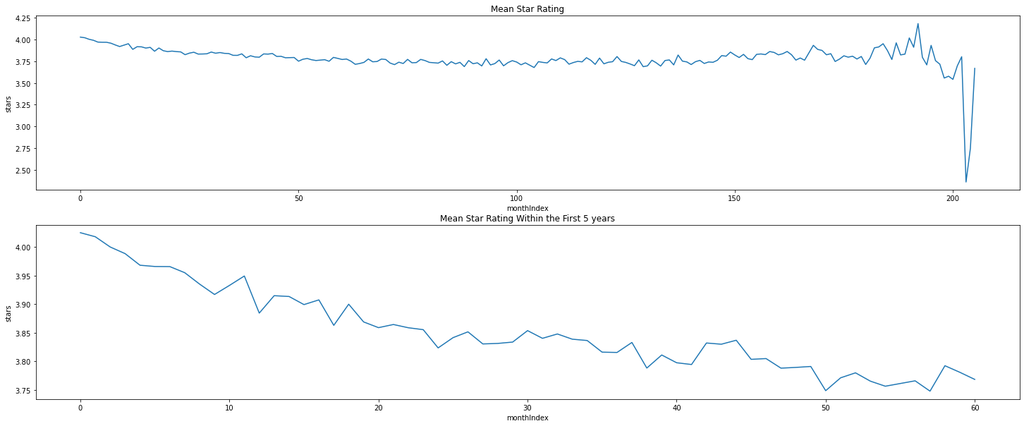

```python
#Part B
#This takes roughly a minute to process
def findMonthIndex(firstDate, reviewDate):
    return (abs((firstDate - reviewDate).days)//30)


_business = businessData.merge(reviewsData.groupby(["business_id"])["date"].min(), how="left",
                                       left_on="business_id", right_on="business_id").dropna()

_business = _business.rename({"date":"firstReviewDate"},axis="columns")


indexedMonths = _business[["business_id", "firstReviewDate"]].merge(reviewsData[["business_id","date","stars"]], how="left",
                           left_on="business_id", right_on="business_id")

indexedMonths["monthIndex"] = indexedMonths.apply(lambda x : findMonthIndex(x.firstReviewDate, x.date), axis=1)
_data = indexedMonths.groupby(["monthIndex"])["stars"].mean().reset_index()

figure = plt.figure(figsize=(25,10))
plt.subplot(211)
plt.title("Mean Star Rating")
deletethis = sns.lineplot(x=_data["monthIndex"], y=_data["stars"], ci=95)
plt.subplot(212)
plt.title("Mean Star Rating Within the First 5 years")
deletethis = sns.lineplot(x=_data.loc[_data["monthIndex"] <= 60]["monthIndex"], y=_data["stars"], ci=95)
```

## Part C: Corellation: Region Price - Stars - Count

By reading the RedfinPhila file, we get the regions' median sale price (aka Region price). Afterwards, we similarly calculate the mean stars of each region, as well as the number of businesses. Finally, we plot each value with eachother and calculate the Coefficient and P-Value using Pearsonr Test.

### Results

For the first graph, with all the data, we see relativly low coefficient and even lower PValues. With the idea to somewhat force a hypothesis from the data, we assume the highest Coefficience (~0.66) to be acceptable. With this in mind, we see high coefficience on the relations SalePrice-Business and SalePrice-Stars. The low PValues confirm the test, and by examining the graphs we can assume:

### Results - Over 200k

This graph shows similar results with lower coefficiencts. Some P-Values have skyrocketed, while others have remained the same. We will however focus on the previous notes.

- SalePrice and Business Count has remained somewhat the same. The smaller dataset explains the increase in P-Value, as well as the decrease in Coefficience. We can still hold true the assumption on their relationship.
- SalePrice and Star Rating has drastically changed! This could be predicted by seeing the graph, but since we ignore the lower priced regions, the star rating on the expensive end remains similar. Therefore there is no significant corelation on the expensive regions and their star rating.

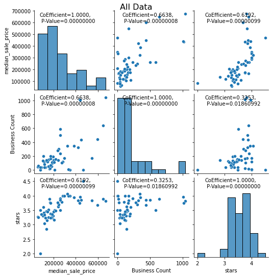

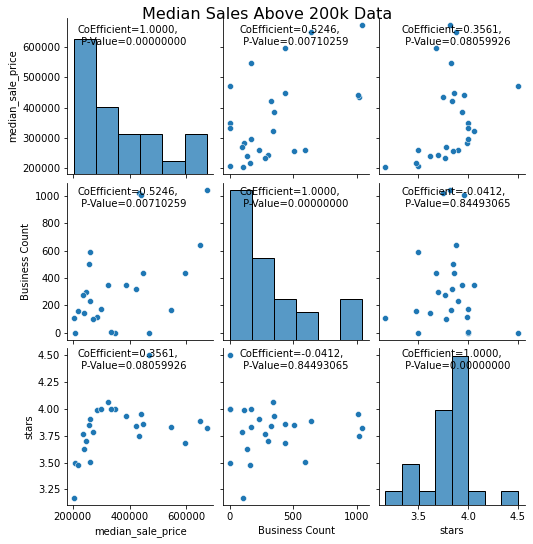

```python
#Part C
realEstateData = pd.read_csv("RedfinPhila.tsv", encoding="latin", sep='\t')
realEstateData["region"] = realEstateData["region"].apply(lambda x: int(x.split(" ")[2]))

#Mean Stars per business
meanStars = businessData.groupby(["postal code"])["stars"].mean().to_frame().sort_values(by="postal code")

#Mean Price by postal code (aka Region)
meanPrice = realEstateData.groupby(["region"])["median_sale_price"].mean().to_frame().sort_values(by="region")
#Business Count by postal code
businessCount = businessData.groupby(["postal code"])["business_id"].count().to_frame()

#Reset indexing for merge
meanPrice = meanPrice.reset_index()
businessCount = businessCount.reset_index()
meanStars = meanStars.reset_index()

#Merge all data to one DataFrame without the region/ZIP codes
estateData = meanPrice.merge(businessCount, how="left", left_on="region", right_on="postal code")\
                    .dropna().drop(["postal code"], axis=1)
estateData = estateData.merge(meanStars, how="left", left_on="region", right_on="postal code")\
                    .dropna().drop(["postal code"], axis=1).drop(["region"], axis=1)
estateData = estateData.rename({"business_id":"Business Count"},axis="columns")

#Plot the data
graph = sns.pairplot(estateData)

#Type on each Graph the Coefficient and P-Value from the pearsonr Test.
dataTypes = ["stars", "Business Count", "median_sale_price"]
for i in range(len(dataTypes)):
    for j in range(len(dataTypes)):
        co, pval = stats.pearsonr(estateData[dataTypes[i]], estateData[dataTypes[j]])
        line = "CoEfficient="+str("{:.4f}".format(co))+ ",\n P-Value=" +str("{:.8f}".format(pval))
        graph.fig.text(1-(0.3*i)-0.25, 0.3*j+0.33, line)
graph.fig.suptitle("All Data", size=16, y=1)

estateData = estateData.loc[estateData["median_sale_price"] > 200_000]
graph = sns.pairplot(estateData)

for i in range(len(dataTypes)):
    for j in range(len(dataTypes)):
        co, pval = stats.pearsonr(estateData[dataTypes[i]], estateData[dataTypes[j]])
        line = "CoEfficient="+str("{:.4f}".format(co))+ ",\n P-Value=" +str("{:.8f}".format(pval))
        graph.fig.text(1-(0.3*i)-0.25, 0.3*j+0.33, line)
null = graph.fig.suptitle("Median Sales Above 200k Data", size=16, y=1)
```

## Part D: Correlation: Star Rating - Price

On this test, we assume a correlation between the star rating and the restaurant's price, using the RestaurantsPriceRange2 attribute to split the data into Expensive and Cheap. The graph generated using this data shows us the mean value, as well as the standard deviation. We can see that there is a difference between the two means, with the expensive restaurants having higher mean stars. The difference in stars is roughly 0.3, which isn't a lot, but it does prove our point. The T-Test's PValue is low enough to confirm our assumption.

## Correlation: Star Rating - Attire

This time, we assume correlation between star rating and the restaurant's attire. With the attire being either Formal or Casual, we once again plot the data. This time, there is an overlap between the two datasets. Their mean has a small difference, but their deviation crosses each other. Therefore, we can say that usually formal attired restaurants have higher star rating than those with formal, but they have a fair overlap. The T-Test confirms the uncertainty of this hypothesis with a relatively high P-Value.

```
              T=4.9928, P-Value=0.000001                                         T=1.4266, P-Value=0.153778
```

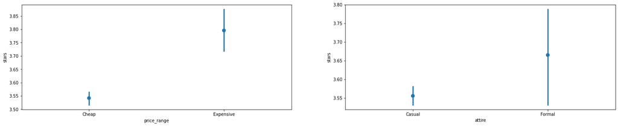

```python
#Part D
figure = plt.figure(figsize=(25,10))
#Filter only restaurants
restaurants = businessData.loc[businessData["categories"].apply(lambda x: "Restaurants" in x or " Restaurants" in x)]
restaurants = restaurants.copy()
#Convert attributes to Dictionaries
restaurants["attributes"] = restaurants["attributes"].apply(lambda x : eval(x))
#Remove restaurants without price range or with None value
restaurants = restaurants.loc[restaurants["attributes"].apply(lambda x: "RestaurantsPriceRange2" in x)]
restaurants = restaurants.loc[restaurants["attributes"].apply(lambda x : x["RestaurantsPriceRange2"] != "None")]


#Set a Price Range column to plot better
restaurants["price_range"] = restaurants["attributes"].apply(lambda x :
                                                             "Cheap" if int(x["RestaurantsPriceRange2"]) <= 2 else "Expensive")

plt.subplot(221)
#Price with Price Range and Mean of stars
graph = sns.pointplot(data=restaurants, x="price_range", y="stars", errorbar=("ci",95), join=False) #Confidense 95%

#T-Test
t, pval = stats.ttest_ind(restaurants["stars"].loc[restaurants["price_range"] == "Expensive"],
                restaurants["stars"].loc[restaurants["price_range"] == "Cheap"])
line = "              T=" + str("{:.4f}".format(t)) + ", P-Value=" + str("{:.6f}".format(pval))

##################################
restaurants = businessData.loc[businessData["categories"].apply(lambda x: "Restaurants" in x or " Restaurants" in x)]
restaurants = restaurants.copy()
restaurants["attributes"] = restaurants["attributes"].apply(lambda x : eval(x))
restaurants = restaurants.loc[restaurants["attributes"].apply(lambda x: "RestaurantsAttire" in x)]
restaurants["attire"] = restaurants["attributes"].apply(lambda x : "Casual" if "casual" in x["RestaurantsAttire"] else "Formal")

plt.subplot(222)
graph = sns.pointplot(data=restaurants, x="attire", y="stars", errorbar=("ci",95), join=False)

t, pval = stats.ttest_ind(restaurants["stars"].loc[restaurants["attire"] == "Formal"],
                          restaurants["stars"].loc[restaurants["attire"] == "Casual"])
line += "                                         T=" + str("{:.4f}".format(t)) + ", P-Value=" + str("{:.6f}".format(pval))
print(line)
```

## Part E: Correlation: Good for Dates - Fancy

In this test we see if there's a linear correlation between restaurants that are fancy and restaurants that are good for dating. Uing the attributes "Romantic" and "Intimate" for GoodForDate and "Classy" and "Upscale" for Fancy, we calculate the Contigency Table.

Most restaurants fall to neither category, having the highest cluster in the False-False category. This is followed by the False-True category, which we can use to assume that most restaurants that are Fancy, tend to be bad for dating. Suprisingly, the rarest type is the True-False, which is the opposite of the above hypothesis, making very few non-fancy restaurants also good for dating. On the other hand, restaurants that are both good for dating and fancy, seem to have a slightly higher count.

The Chi Value confirms a linear correlation between our data, and the low P-Value confirms it.

```python
#Part E

#Applies the 4 basic values we expect to see as False, should they not exist.
def applyExpectedValues(data):
    if "romantic" not in data:
        data["romantic"] = False
    if "intimate" not in data:
        data["intimate"] = False
    if "classy" not in data:
        data["classy"] = False
    if "upscale" not in data:
        data["upscale"] = False
    return data


#Once more, we pick out the restaurants
restaurants = businessData.loc[businessData["categories"].apply(lambda x: "Restaurants" in x or " Restaurants" in x)]
restaurants = restaurants.copy()
restaurants["attributes"] = restaurants["attributes"].apply(lambda x : eval(x))
#Filter None or non-existing Ambiences
restaurants = restaurants.loc[restaurants["attributes"].apply(lambda x: "Ambience" in x)]
restaurants = restaurants.loc[restaurants["attributes"].apply(lambda x: x["Ambience"] != "None")]

#Create a column only for Ambience for better reading/filtering
restaurants["ambience"] = restaurants["attributes"].apply(lambda x : eval(x["Ambience"]))
#Add non existant values to the dictionary
restaurants["ambience"] = restaurants["ambience"].apply(lambda x: applyExpectedValues(x))

#Add 2 extra columns to store our categories.
restaurants["goodForDate"] = restaurants["ambience"].apply(lambda x: True if (x["romantic"] or x["intimate"]) else False)
restaurants["fancy"] = restaurants["ambience"].apply(lambda x: True if (x["upscale"] or x["classy"]) else False)
#the 'goodForDate' column.

#High Chi, Low Col, No correlation
cont = pd.crosstab(restaurants["goodForDate"], restaurants["fancy"])
stat, p, dof, expected = stats.chi2_contingency(cont)

print("Chi Value = ", stat)
print("P-Value = ", p)
cont
```

```
Chi Value =  128.27290661248816
P-Value =  9.782338969793875e-30
```

| fancy goodForDate | False | True |
| --- | --- | --- |
| False | 3014 | 684 |
| True | 99 | 105 |

## Part Z: Correlation: Type of Business - Regions' Price

This test was a bit more tricky. With no easy way to showcase the data, we tried several manners. The main graph we will focus on is the first one we plotted. The manner we decided to compare each region is using the Cosine Difference of their Categorical Vector.

- The Categorical Vector is a vector of 0s and 1s for each category. All vectors are of the same length.
- All vectors, after being calculated, have their values divided by the amount of businesses in that region, the calculate their frequency across the region.

Having found this, we compare every region with each other, and find their most similar vector using cosine vector distance. The final plot shows each region, represented by a dot, plotted on their regions' price and their most similar region's vector. While imperfect, this shows that all regions are somewhat similar to each other, regardless regions' price.

Further testing, using heatmaps and 3D plots shows again a great resemblance around the same region across all price ranges. Using Pearsonr Correlation, we get a small value, showing the small correlation in our data. This however is also supported by a large P-Value, showing an uncertainty in our test.

```
(-0.09880702956061026, 0.48586822093640014)
```

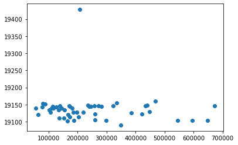

```python
#Part Z
#By finding the best match (and plotting our heatmap later on) we see all businesses gathered around the same area.
#That means that in general, the areas' price does not affect the category.
def findBestMatch(pc):
    global categoricalData
    vector = categoricalData.loc[pc].to_list()
    bestMatch = -1
    bestIndex = -1

    for p in categoricalData.index:
        if p == pc:
            continue
        dis = 1-distance.cosine(vector, categoricalData.loc[p].to_list())
        if dis > bestMatch:
            bestMatch = dis
            bestIndex = p
    return bestIndex

#Load the mean price of each area
realEstateData = pd.read_csv("RedfinPhila.tsv", encoding="latin", sep='\t')
realEstateData["region"] = realEstateData["region"].apply(lambda x: int(x.split(" ")[2]))
meanPrice = realEstateData.groupby(["region"])["median_sale_price"].mean().to_frame().reset_index()

categoryBusiness = businessData.copy()
categoryBusiness["categories"] = categoryBusiness["categories"].apply(lambda x : [i.strip() for i in x])

#Turn categories into their respective column. ~900 columns for each postal code.
categoricalData = pd.DataFrame()
categoricalData["categories"] = categoryBusiness.groupby(["postal code"]).apply(lambda x :
                                                  x["categories"].explode().value_counts().to_dict())
categoricalData = categoricalData["categories"].apply(pd.Series).fillna(0).drop(["Restaurants"], axis=1)
#Turn them into a frequency by dividing with the sum of the areas businesses.
categoricalData = categoricalData.apply(lambda x : x / categoricalData.sum(axis=1))

#Find for each region X, a region Y that mostly resembles its vector of categories
bestMatches = categoricalData.reset_index()["postal code"].apply(lambda x : findBestMatch(x))
plotData = categoricalData.reset_index()
plotData["bestMatch"] = bestMatches
plotData = plotData.merge(meanPrice, how="left", left_on="postal code", right_on="region").dropna()

#Plot the mean price of the region with their best match.
deletethis = plt.scatter(plotData["median_sale_price"], plotData["bestMatch"])

co, pval = stats.pearsonr(plotData["bestMatch"], plotData["median_sale_price"])
co, pval
```

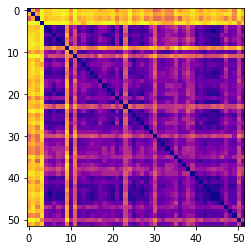

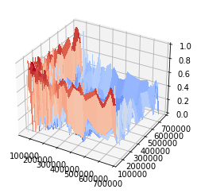

```python
#Further plots/attempts to show my point
removed = categoricalData.reset_index().merge(meanPrice, how="left", left_on="postal code", right_on="region")
removed = removed.loc[removed["median_sale_price"].isnull()]["postal code"]
_df = categoricalData.reset_index()
_df = _df[~_df["postal code"].isin(removed)]
prevDF = _df.copy()
_df = _df.drop(["postal code"], axis=1)
distances = distance.pdist(_df[_df.columns], "cosine")
_df = pd.DataFrame(distance.squareform(distances))

cmap = cm.get_cmap('plasma', 20)
plt.imshow(_df, cmap=cmap)


distanceMatrix = _df.values
prevDF = prevDF.merge(meanPrice, how="left", left_on="postal code", right_on="region").dropna().sort_values(by="median_sale_price")
_df["code"] = prevDF["postal code"].values
meanPrices = prevDF["median_sale_price"].values
v = [meanPrices]*52

fig, ax = plt.subplots(subplot_kw={"projection": "3d"})
surf = ax.plot_surface(np.array(v),
                       np.array(v).T,
                       np.array(distanceMatrix), cmap=cm.coolwarm, linewidth=0, antialiased=False)
```

## Part H (Bonus): Correlation Work Hours - Regions' Price

Let's form this hypothesis. We have already seen in Part C that there is a correlation in regions' price and the count of businesses. This can be the result of higher rent price in more expensive regions. Let's assume that's true. With this in mind, a business has to put more work hours to stay afloat. With this in mind, using the hours column on each business, we calculate the mean work hours on each region, and compare it to the regions' price.

After plotting the data, we see little difference in the work hours across all regions. In fact, after running the correlation test, we find negative correlation, if any. The P-Value is rather high to say anything for certain, which makes sense, since our dataset for expensive regions is rather small.

## Conclusion

We can assume our hypothesis wrong. All regions have similar mean work hours, regardless of price. Even if we accept our P-Value of ~0.2 to be enough, the Pearsonr Correlation is too low to be of scientific interest.

```
Coefficient =  -0.17629325279062621   P-Value =  0.21123221195936015
```

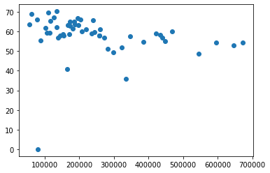

```python
#Part H (Bonus)
def countWorkHours(schedule):
    workSchedule = eval(schedule)
    totalHours = 0
    for day in workSchedule.keys():
        w = workSchedule[day].split("-")
        start = datetime.datetime.strptime("1-10-20 " + w[0].split(":")[0] + ":" + w[0].split(":")[1], "%d-%m-%y %H:%M")
        end = datetime.datetime.strptime("1-10-20 " + w[1].split(":")[0] + ":" + w[1].split(":")[1], "%d-%m-%y %H:%M")
        totalHours += (end-start).seconds/3600
    return totalHours

#Let's go with this hypothesis. Due to the high rent in more expensive areas, the business owners must be working
#way more than those in cheaper areas, to keep up with all the costs. Therefore, we hypothesize, that the mean
#work hours of an expensive area should be greater than that in a cheap area.


df = businessData.copy()

df["workHours"] = df["hours"].apply(lambda x : countWorkHours(x))

areaWorkHours = df.groupby("postal code")["workHours"].mean().to_frame().reset_index()

realEstateData = pd.read_csv("RedfinPhila.tsv", encoding="latin", sep='\t')
realEstateData["region"] = realEstateData["region"].apply(lambda x: int(x.split(" ")[2]))
meanPrice = realEstateData.groupby(["region"])["median_sale_price"].mean().to_frame().reset_index()

plotData = areaWorkHours.merge(meanPrice, how="left", left_on="postal code", right_on="region").dropna()

plt.scatter(plotData["median_sale_price"], plotData["workHours"])
co, pval = stats.pearsonr(plotData["workHours"], plotData["median_sale_price"])
print("Coefficient = ", co, "  P-Value = ", pval)
```